# GoM cod and haddock RDM

Lou Carr-Harris

2024-06-24

This file is an exploratory analysis of the effect of climate-induced shifts in angler catch-per-trip of Gulf of Maine cod and haddock. Results are based on 100 iterations of the recreation demand model. The RDM is calibrated to 2020 fishery conditions.

### Bottom temperatures

#### By decade

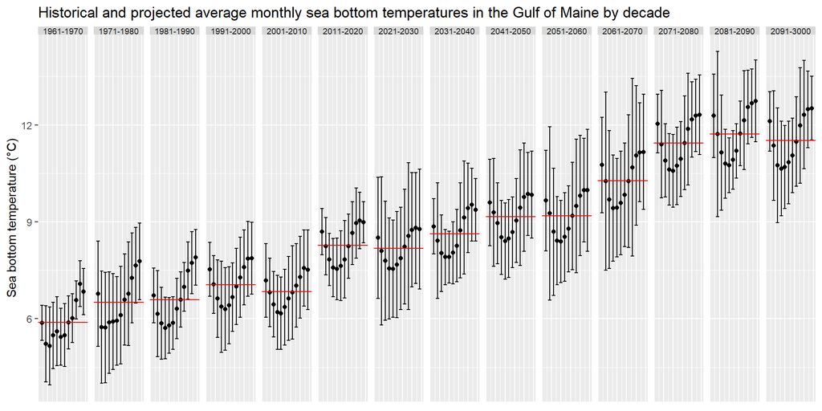

Mean monthly bottom temps by decade/year, red line indicates decadal average. Bars represent mean monthly temp +/- 1.96*standard dev.

#### By year/decade

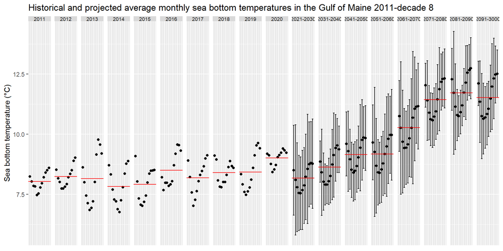

Mean monthly bottom temps by decade/year, red line indicates decadal average. Bars represent mean monthly temp +/- 1.96*standard dev.

#### Diff. from 2020

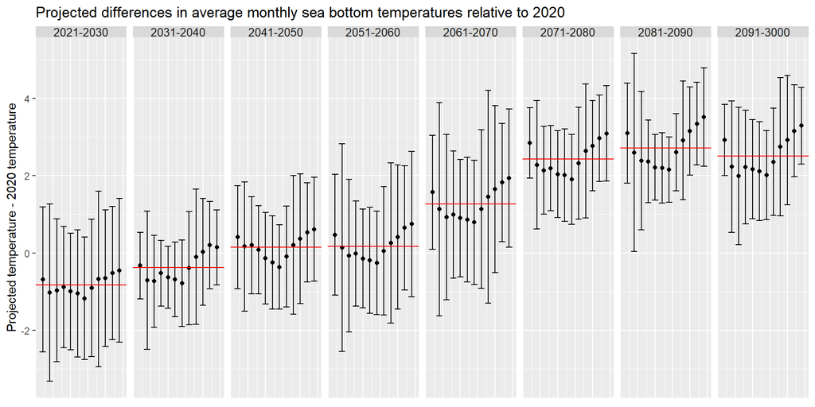

Projected differences in average monthly sea bottom temperatures relative to 2020. Bars represent lower and upper bounds of the projected average monthly temperatures. Red lines indicate differences between the decadal and 2020 annual average.

#### Diff. from 2011-2020

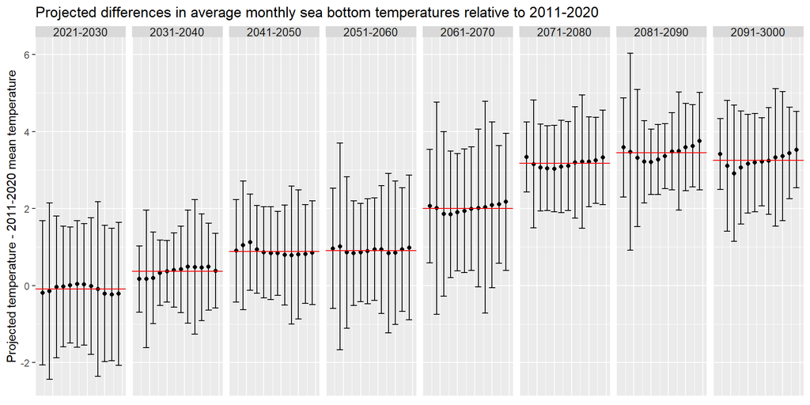

Projected differences in average monthly sea bottom temperatures relative to 2011-2020. Bars represent lower and upper bounds of the projected average monthly temperatures. Red lines indicate differences between the decadal and 2011-2020 average. ### {-}

### Baseline (2020) fishery

#### Fishery statistics

Index “_i” indicates per choice occasion variable

```
           variable     mean       sd
               draw     50.5  29.0115
    estimated_trips 312755.1   0.9653
 n_choice_occasions   483934 2193.714
      tot_cod_catch 588077.5 1903.489
       tot_keep_cod 5044.494  53.3831
        tot_rel_cod   583033 1897.925
     tot_hadd_catch  1918895  4220.46
      tot_keep_hadd  1004515 2038.446
       tot_rel_hadd 914379.9 2380.872
         cod_keep_i   0.0104    1e-04
        hadd_keep_i   2.0758   0.0091
      cod_keep_trip   0.0161    2e-04
     hadd_keep_trip   3.2118   0.0065
        cod_catch_i   1.2152   0.0067
       hadd_catch_i   3.9653    0.018
     cod_catch_trip   1.8803   0.0061
    hadd_catch_trip   6.1355   0.0135
```

#### Utililty parameters

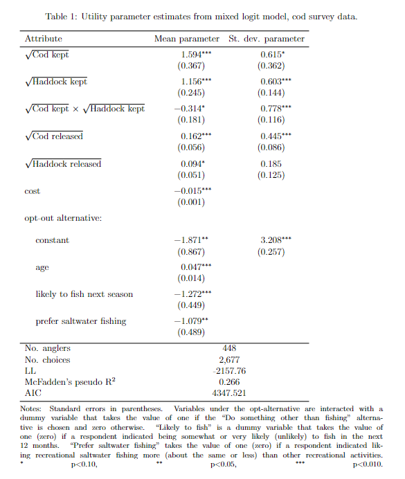

### Baseline welfare calculations

After calibrating the simulation model to 2020 fishery conditions, I re-ran the model under two closure scenarios: (a) bag limits for both cod and haddock set to zero, and (b) bag limits for cod only set to zero.  
$~$

#### Scenario (a): close both fisheries

```
            variable     mean       sd
              cv_sum 30461985 157733.2
       tot_cod_catch 479327.9 2081.661
      tot_hadd_catch  1539889  5020.69
          cod_keep_i        0        0
         hadd_keep_i        0        0
       cod_keep_trip        0        0
      hadd_keep_trip        0        0
         cod_catch_i   0.9895   0.0065
        hadd_catch_i   3.1788    0.019
      cod_catch_trip   1.8434   0.0068
     hadd_catch_trip   5.9222   0.0132
             cv_trip 117.1531    0.681
 percent_redux_trips -16.8614   0.1755
```

#### Scenario (b): close cod only

```
            variable    mean       sd
              cv_sum  429052  85388.3
       tot_cod_catch  586237 1958.148
      tot_hadd_catch 1916058 4329.256
          cod_keep_i       0        0
         hadd_keep_i  2.0701   0.0097
       cod_keep_trip       0        0
      hadd_keep_trip  3.2133   0.0066
         cod_catch_i  1.2102   0.0063
        hadd_catch_i  3.9553   0.0186
      cod_catch_trip  1.8785   0.0061
     hadd_catch_trip  6.1396   0.0126
             cv_trip  1.3749    0.274
 percent_redux_trips -0.2152   0.0491
```

### Historical projected fishery outcomes

From Jorge’s notes: we will run the bioeconomic model for each of the years in the period 2010-2019 as follows: i) calibrate the model for year 201X, ii) predict year 201X+1 under independent and dependent catch-per trip for cod and haddock, then calibrate year 201X+1 and predict 201X+2 , and so forth. Jorge will generate the catch-per-trip data for each year for both the independent and correlated scenarios as follows: i) use the biomass and ocean bottom temperatures for each year in 2010-2019 to calculate the expect catch-per-trip for cod and haddock, ii) add to the expect catch-per-trip the simulated residuals (correlated or independent) to generate the independent and correlated samples to use in the simulations.

I’ve included a plot of “bag limit potential” by species to visualize the stringency of regulations. To create this variable, I multiply the number of trips in 201X by season by the bag limit in 201X+1. In cases where the haddock bag limit was unlimited, I set the bag limit to 20 given the highest observed haddock bag limit over the series was 15. The model does not account for changing size limits over the historical period. Instead, it assumes that the proportion of legal-size fish in 201X+1 is the same as the proportion of legal-size fish in 201X. This is an issue we may want to revisit and correct for.

I’ve also included a plot of bag limits by month and species. These are bag limits for the private boat mode, which only vary from the for-hire sector in 2020 and in 2017 for the state of MA. The 2017 MA regulations are applied to all trips in the model. Since the model time step is bi-monthly (two periods per month), I computed the average bag limit by month.

One way to compare CV outcomes to regulatory stringency is to compute changes in bag limits or bag limit potential between years 201X and 201X+1. I have not gotten to this yet.  
$~$

#### bag limits

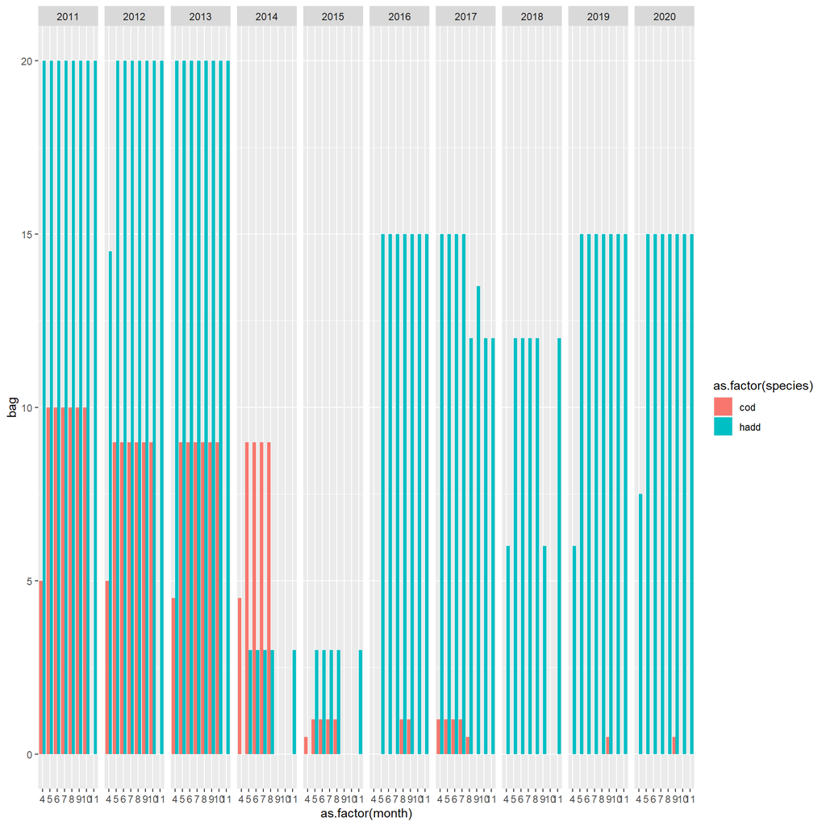

#### bag limit potential

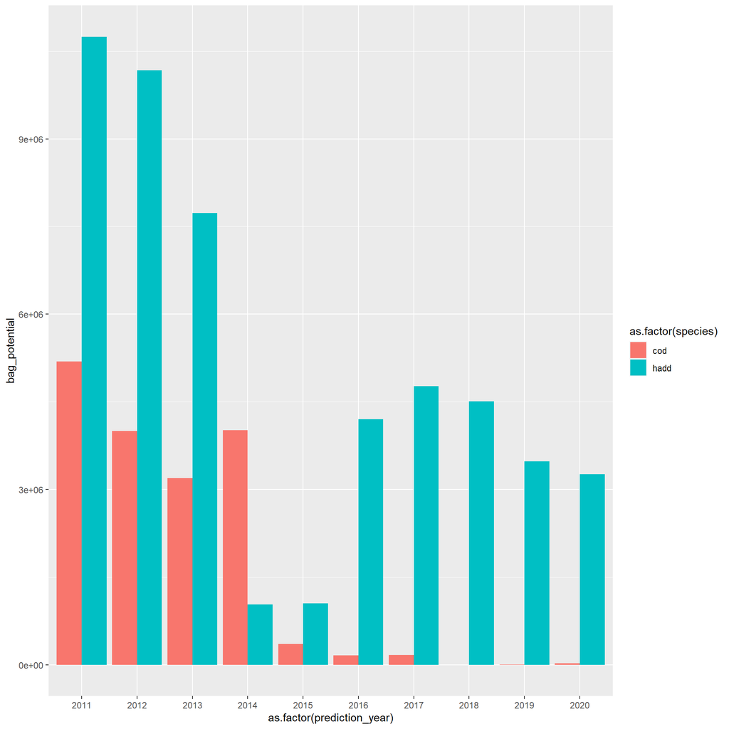

#### Total CV

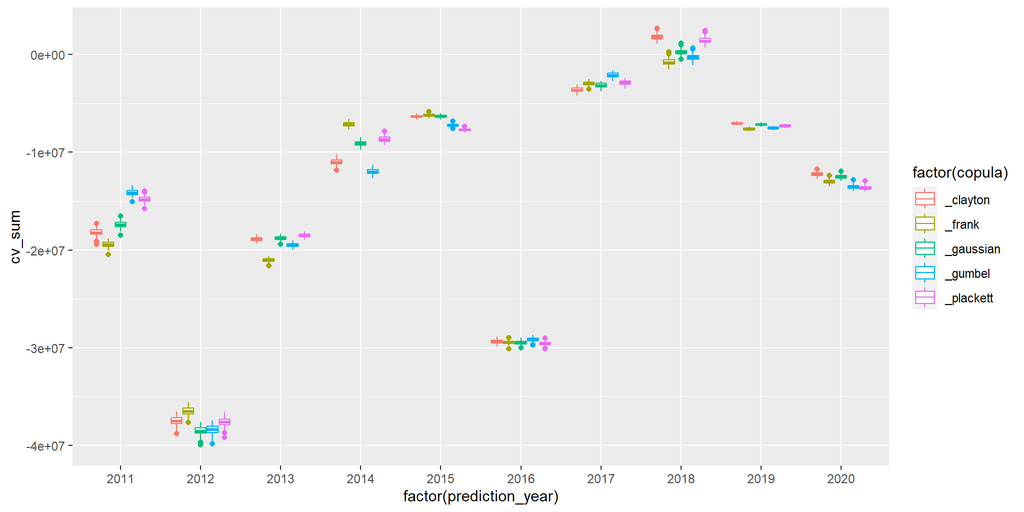

#### Difference in total CV between ind. and corr (tot_cv_corr-tot_cv_ind)

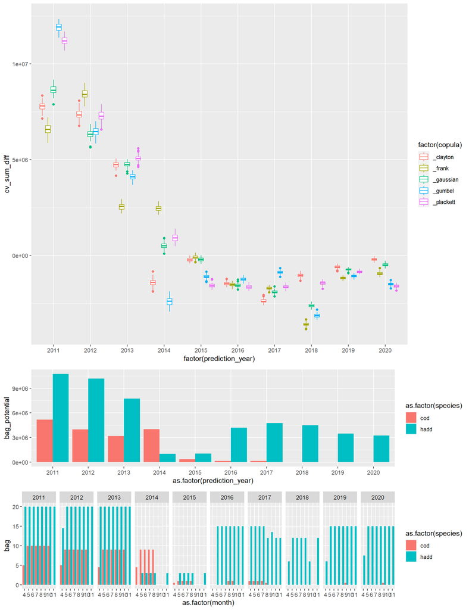

#### CV per trip

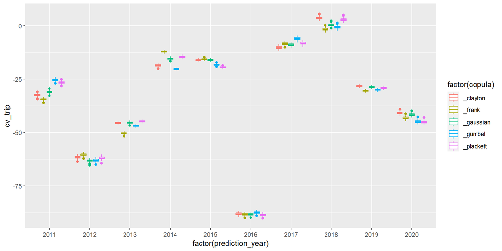

#### Difference in CV per trip between ind. and corr (trip_cv_corr-trip_cv_ind)

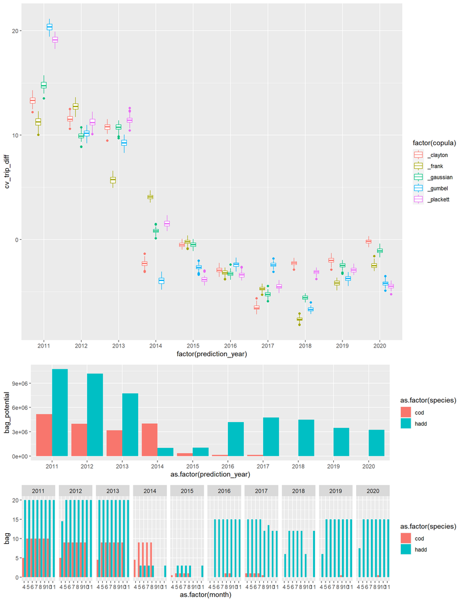

#### K-tau catch (correlated)

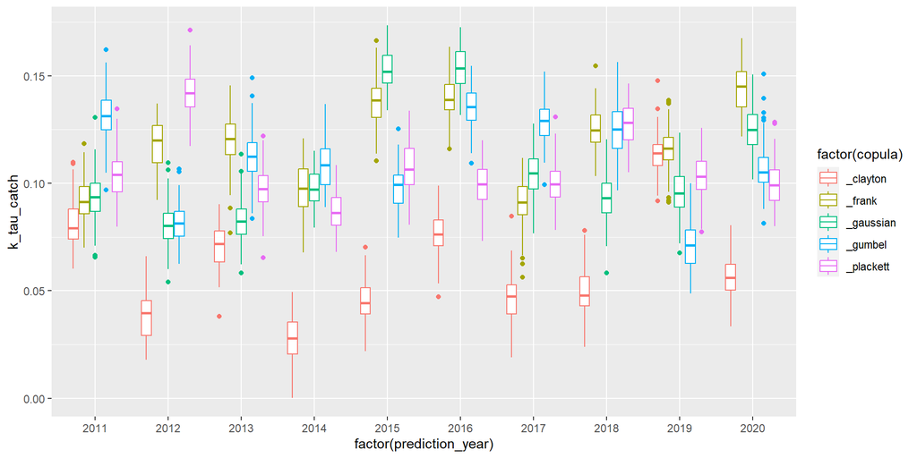

#### K-tau keep (correlated)

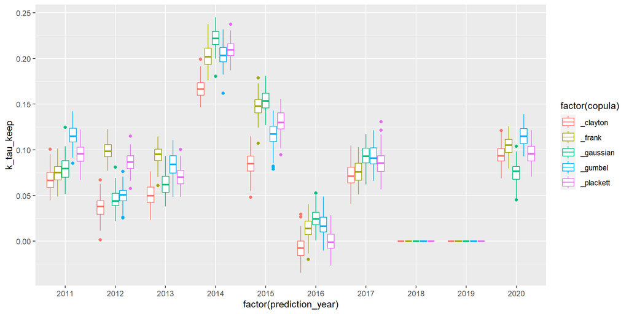

#### K-tau catch (independent)

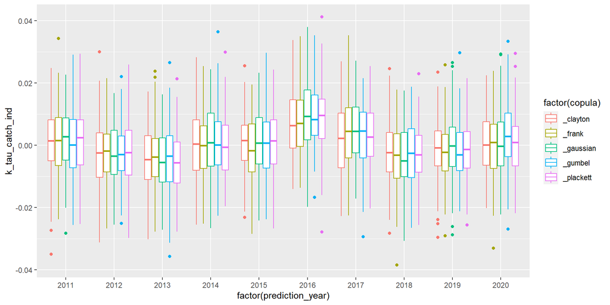

#### K-tau keep (independent)

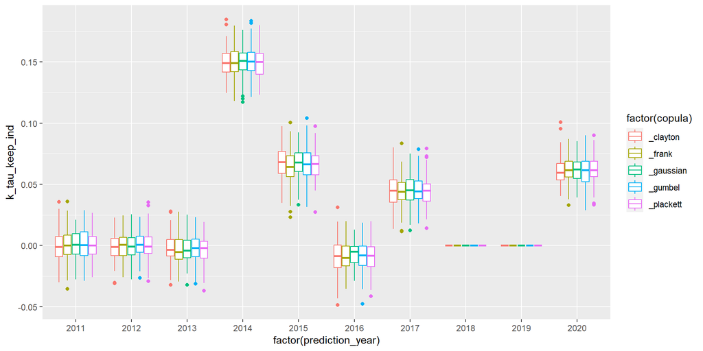

#### K-tau catch vs. k-tau keep (clayton correlated)

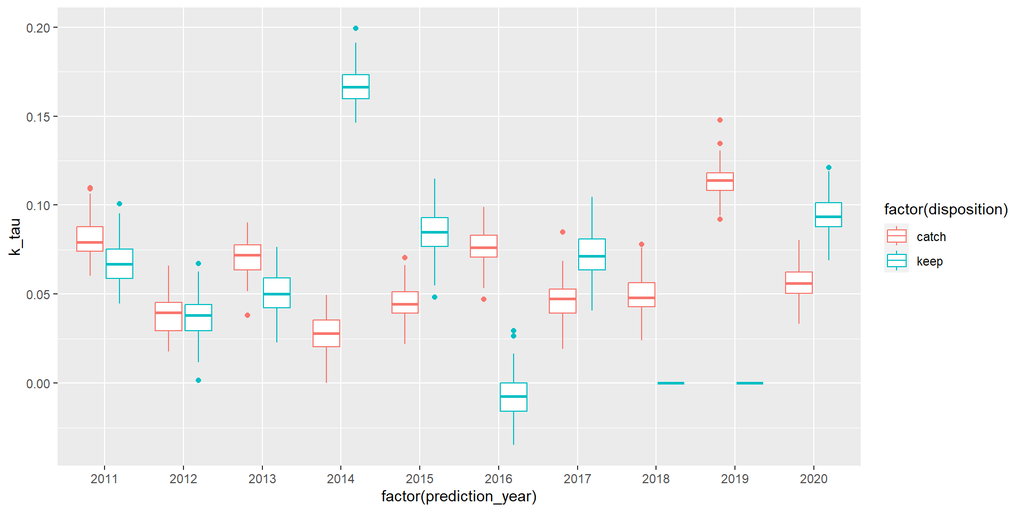

### {-}

### Annual projected fishery outcomes under climate-induced changes in catch-per-trip

Each tab contains different projected fishery outcomes across copula models.

#### CV as a proportion of CV under full-closure of 2020 fishery

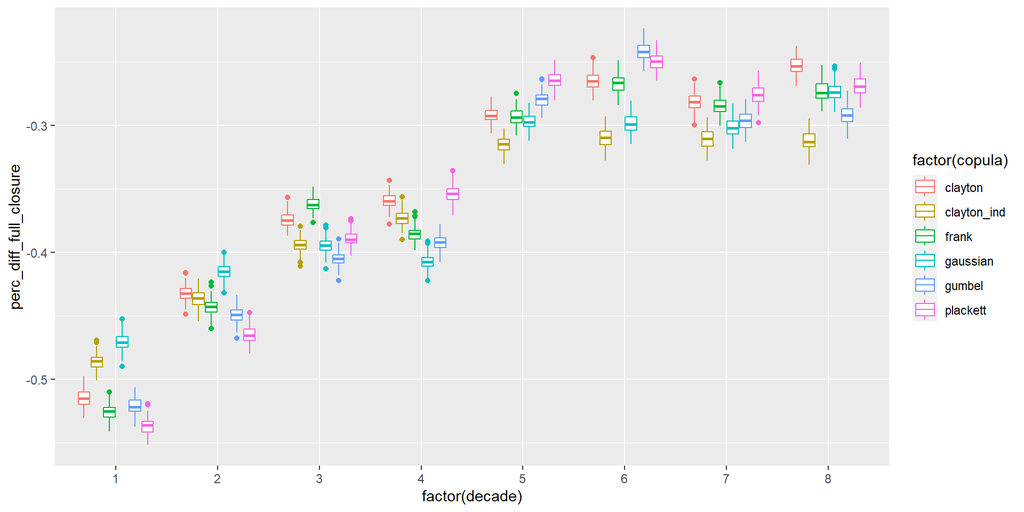

#### Total CV

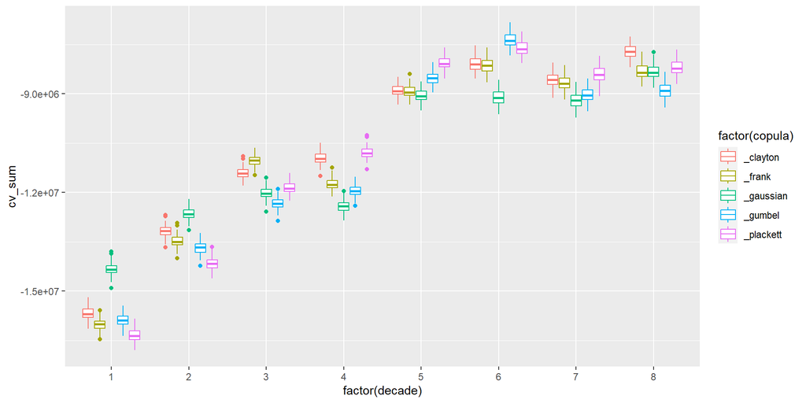

#### Difference in total CV between ind. and corr (tot_cv_corr-tot_cv_ind)

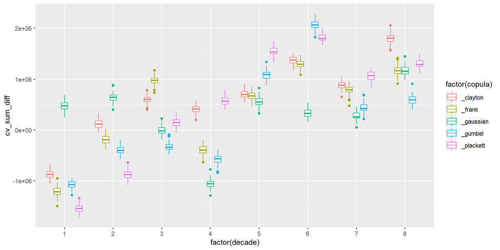

#### CV per trip

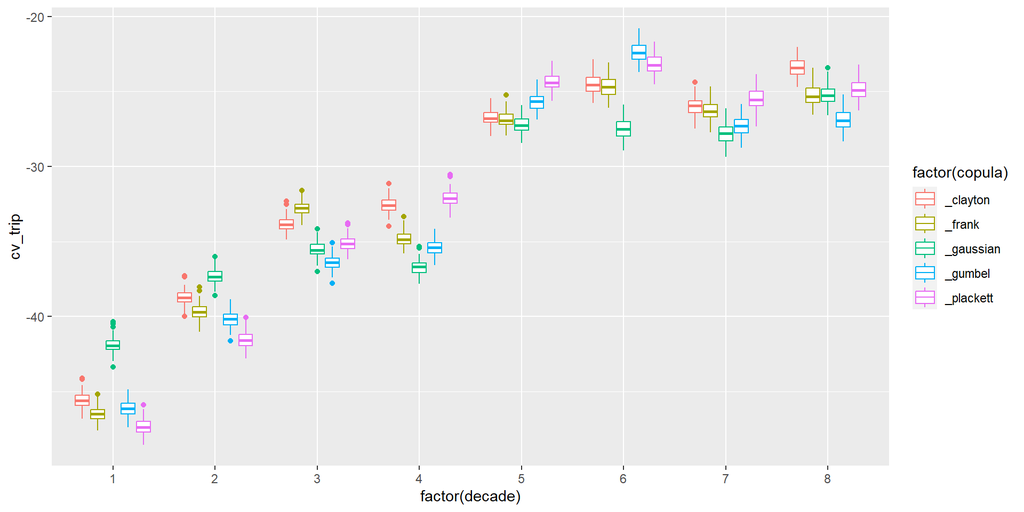

#### Difference in CV per trip between ind. and corr (cv_trip_corr-cv_trip_ind)

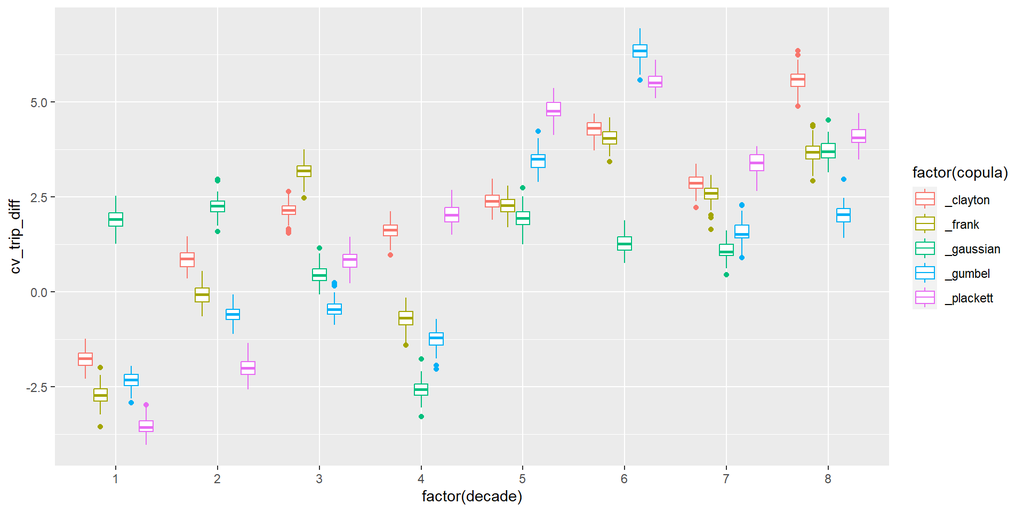

#### cod catch

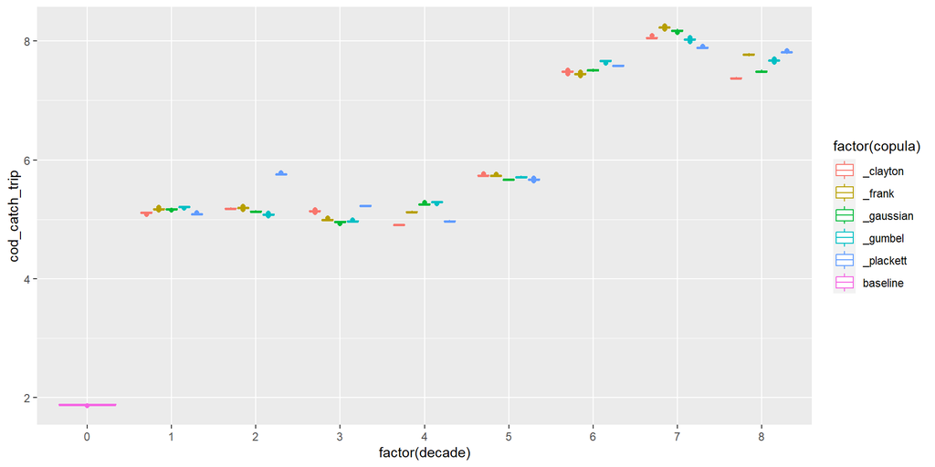

#### cod keep

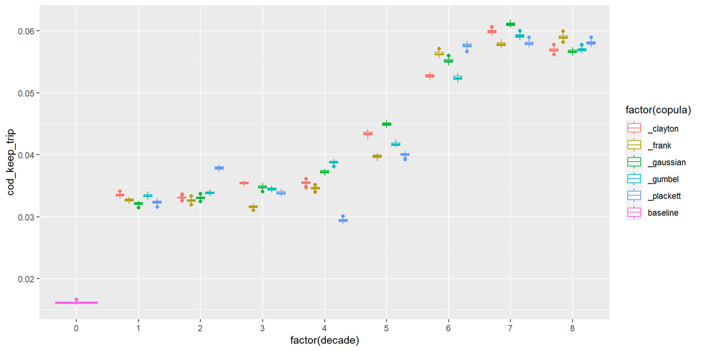

#### hadd catch

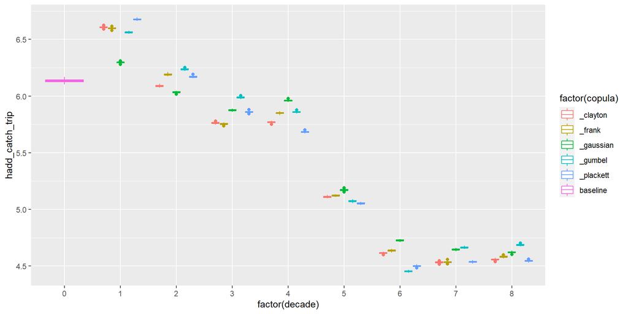

#### hadd keep

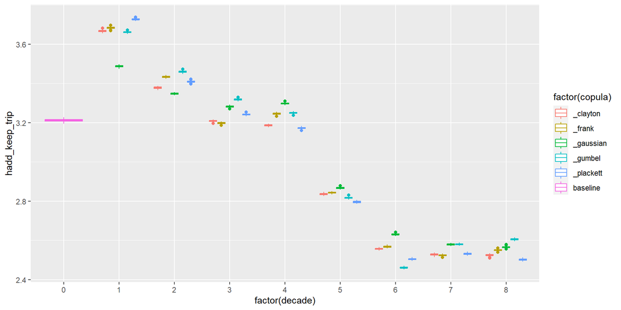

#### ktau keep

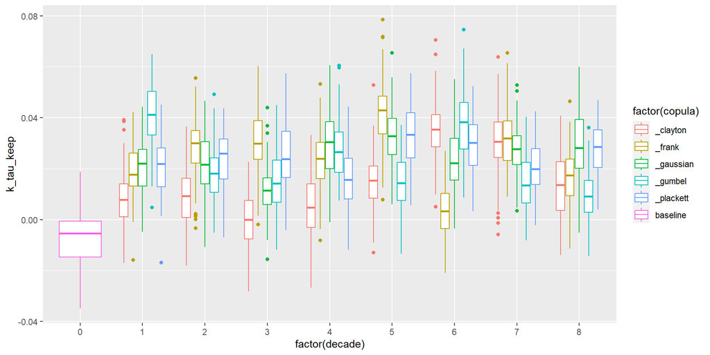

#### ktau catch

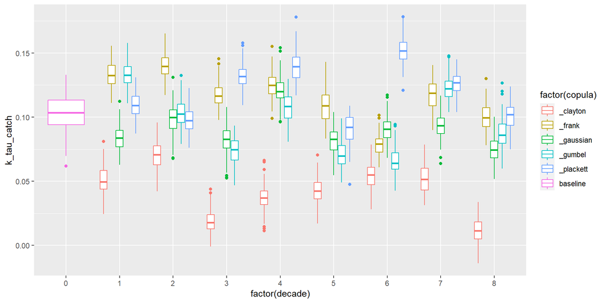

### {-}

### OLS meta-analaysis of simulation results

The following OLS regression uses as data the 10 sets of results above (5 copulas, each with independent and correlated catch).

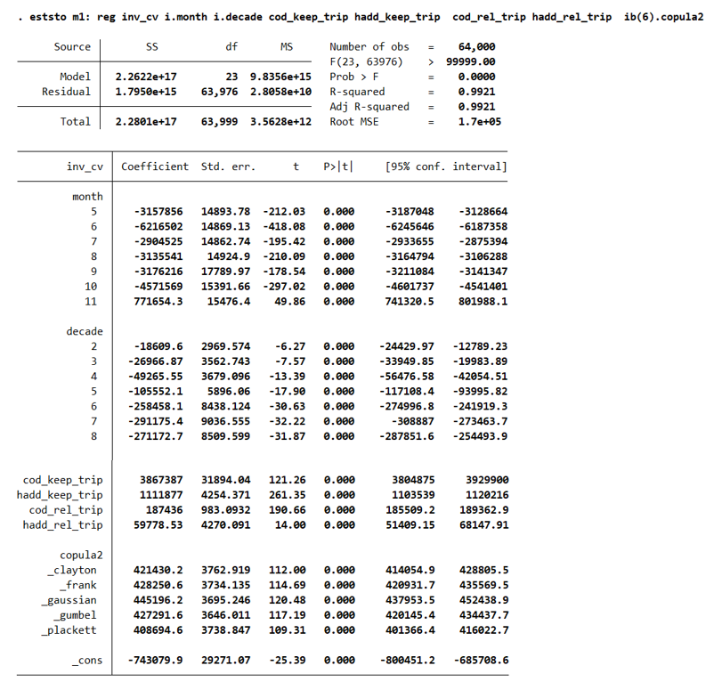

OLS results of total monthly CV